# Group6_Assignment1

Tanisha Yadav, Zhicong Hu, Roman Vazquez Lorenzo, Emma Flutsch, Sarah Wu

# Assignment 1: Prices, Returns and Portfolios

## AM14 Empirical Finance - Study Group 6

## Introduction

In this assignment, we aim to understand the daily and monthly movement of prices and returns of six different stocks. We also compared the total return with and without investing dividends. We utilize the line graphs and statistical properties such as mean, variance, skewness and Kurtosis to comprehend the returns for Microsoft, GE and S&P500. After conducting our analysis on individual securities, we went ahead and looked at the portfolio’s risks and returns.

## Q1

> Data about Microsoft, ExxonMobil (previously Exxon), General Electric, JP Morgan Chase (previously Chemical Banking and Chase Manhattan), Intel, Citigroup (previously Primerica and Travellers Group) was downloaded from the CRSP (The Center for Research in Security Prices) data base via WRDS (Wharton Research Service). Additionally, it contains value-weighted total returns and total returns excluding dividends for the CRSP index that contains stocks from NYSE, AMEX, and NASDAQ, as well as the total return for the S&P 500 Composite Index.

```r
# loading PS1 Monthly data
monthly_data <- read_excel(here("Data", "PS1_Monthly.xlsx"))

# glimpse of the data
glimpse(monthly_data)
```

```
## Rows: 1,817
## Columns: 18
## $ PERMNO   <dbl> 10107, 10107, 10107, 10107, 10107, 10107, 10107, 10107, 10107~
## $ date     <dbl> 19891229, 19900131, 19900228, 19900330, 19900430, 19900531, 1~
## $ TICKER   <chr> "MSFT", "MSFT", "MSFT", "MSFT", "MSFT", "MSFT", "MSFT", "MSFT~
## $ COMNAM   <chr> "MICROSOFT CORP", "MICROSOFT CORP", "MICROSOFT CORP", "MICROS~
## $ PRIMEXCH <chr> "Q", "Q", "Q", "Q", "Q", "Q", "Q", "Q", "Q", "Q", "Q", "Q", "~
## $ DIVAMT   <dbl> NA, NA, NA, NA, 0, NA, NA, NA, NA, NA, NA, NA, NA, NA, NA, NA~
## $ FACPR    <dbl> NA, NA, NA, NA, 1.0, NA, NA, NA, NA, NA, NA, NA, NA, NA, NA, ~
## $ PRC      <dbl> 87.000, 92.500, 98.750, 110.750, 58.000, 73.000, 76.000, 66.5~
## $ RET      <dbl> 0.000000, 0.063218, 0.067568, 0.121519, 0.047404, 0.258621, 0~
## $ BID      <dbl> 87.00, 92.25, 98.75, 110.50, 57.75, 72.75, 76.00, 66.25, 61.5~
## $ ASK      <dbl> 87.250, 92.500, 99.250, 110.750, 58.000, 73.000, 76.250, 66.5~
## $ CFACPR   <dbl> 144, 144, 144, 144, 72, 72, 72, 72, 72, 72, 72, 72, 72, 72, 7~
## $ RETX     <dbl> 0.000000, 0.063218, 0.067568, 0.121519, 0.047404, 0.258621, 0~
## $ vwretd   <dbl> 0.018295, -0.070115, 0.014901, 0.024140, -0.028286, 0.088936,~
## $ vwretx   <dbl> 0.015516, -0.071949, 0.010958, 0.021618, -0.030565, 0.084650,~
## $ ewretd   <dbl> -0.012375, -0.046408, 0.015434, 0.021315, -0.028117, 0.045675~
## $ ewretx   <dbl> -0.014518, -0.048037, 0.013844, 0.019445, -0.029637, 0.043838~
## $ sprtrn   <dbl> 0.021417, -0.068817, 0.008539, 0.024255, -0.026887, 0.091989,~
```

```r
# Convert date column to date variable
monthly_data$date <- ymd(monthly_data$date)
```

## Q2

```r
# Calculating the total return index for Microsoft
MSFT <- data.frame(date = filter(monthly_data, TICKER == "MSFT")$date,
                   MSFT_RET = filter(monthly_data, TICKER == "MSFT")$RET,
                   MSFT_RETX = filter(monthly_data, TICKER == "MSFT")$RETX)

MSFT <- MSFT %>%
  mutate(MSFT_VALUE = cumprod(1 + MSFT_RET),
         MSFT_VALUEX = cumprod(1 + MSFT_RETX))

cat(paste0("Total Return of Microsoft reinvesting dividends: ", paste0(round(MSFT[nrow(MSFT),"MSFT_VALUE"], 4)*100, "%"), "\nTotal Return of Microsoft without reinvesting dividends: ", paste0(round(MSFT[nrow(MSFT),"MSFT_VALUEX"], 4)*100, "%")))
```

```
## Total Return of Microsoft reinvesting dividends: 11505.38%
## Total Return of Microsoft without reinvesting dividends: 7360.03%
```

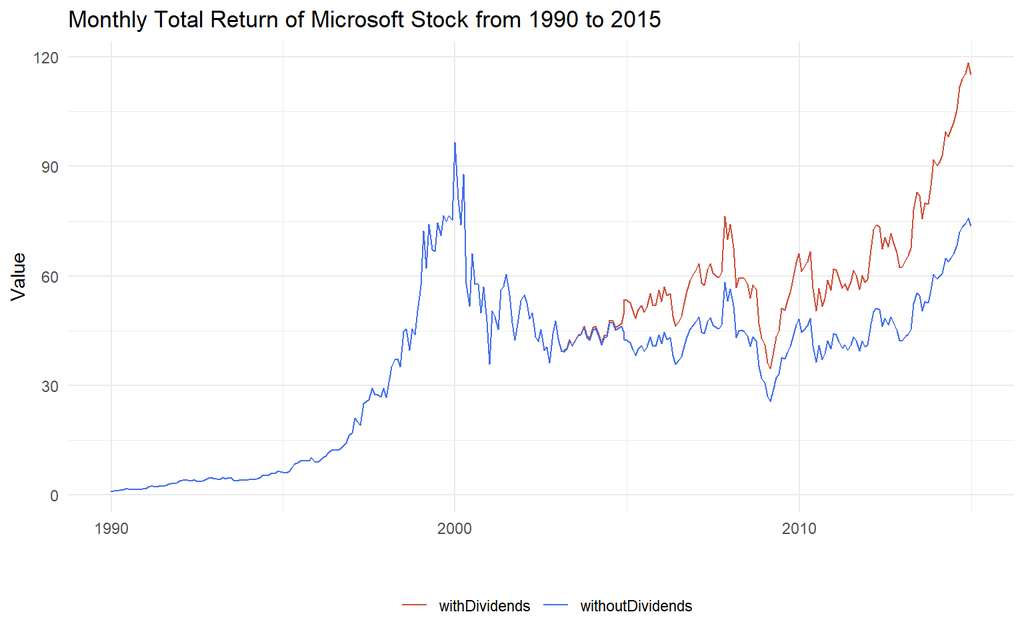

```r
# Plotting the returns of Microsoft
ggplot(data = MSFT, aes(x = date)) +
  geom_line(aes(y = MSFT_VALUE, color = "withDividends")) +
  geom_line(aes(y = MSFT_VALUEX, color = "withoutDividends")) +
  scale_colour_manual("",
                      breaks = c("withDividends", "withoutDividends"),
                      values = c("tomato3", "royalblue2")) +
  theme_minimal() +
  theme(legend.position = "bottom") +
  labs(title = "Monthly Total Return of Microsoft Stock from 1990 to 2015",
       x = "",
       y = "Value")
```

```r
# Calculating the total return index for General Electric
GE <- data.frame(date = filter(monthly_data, TICKER == "GE")$date,
                 GE_RET = filter(monthly_data, TICKER == "GE")$RET,
                 GE_RETX = filter(monthly_data, TICKER == "GE")$RETX)

GE <- GE %>%
  mutate(GE_VALUE = cumprod(1 + GE_RET),
         GE_VALUEX = cumprod(1 + GE_RETX))

cat(paste0("Total Return of Microsoft reinvesting dividends: ", paste0(round(GE[nrow(GE),"GE_VALUE"], 4)*100, "%"), "\nTotal Return of Microsoft without reinvesting dividends: ", paste0(round(GE[nrow(GE),"GE_VALUEX"], 4)*100, "%")))
```

[output not shown]

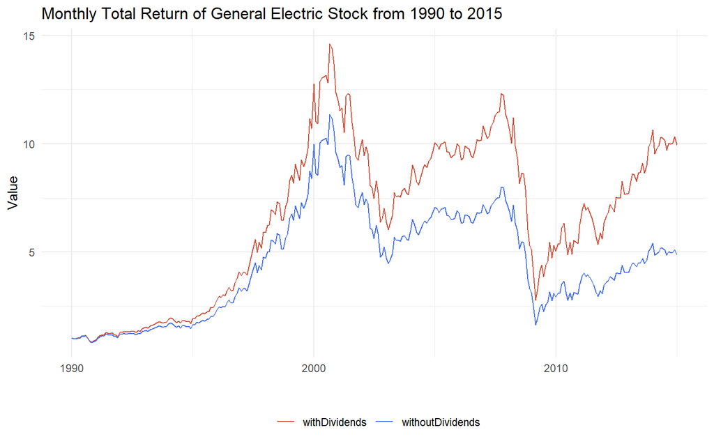

```r
# Plotting the returns of General Electric
ggplot(data = GE, aes(x = date)) +
  geom_line(aes(y = GE_VALUE, color = "withDividends")) +
  geom_line(aes(y = GE_VALUEX, color = "withoutDividends")) +
  scale_colour_manual("",
                      breaks = c("withDividends", "withoutDividends"),
                      values = c("tomato3", "royalblue2")) +
  theme_minimal() +
  theme(legend.position = "bottom") +
  labs(title = "Monthly Total Return of General Electric Stock from 1990 to 2015",
       x = "",
       y = "Value")
```

> The two figures above showcase Microsoft and GE’s monthly total returns, including (red) and excluding (blue) emitted dividends. Microsoft started paying dividends in 2003, which is reflected in the plot, whilst GE started paying them in 1989. It is interesting to note that despite being in different industries, both companies return follow a similar pattern, however at different values (Microsoft’s being much higher, reaching 90+ in the early 2000s). Both companies seem to have been impacted by current events, with a dip in 2001, and another in 2008. However, Microsoft recovered from the 2007-2008 financial crisis and is now at his highest value, whilst GE did not recover as well. Nowaday it is still suffering from its own scandals, being accused of fraud in 2019.

```r
# Calculating the total return index for S&P 500
SP500 <- data.frame(date = filter(monthly_data, TICKER == "MSFT")$date,
                    SP500_RET = filter(monthly_data, TICKER == "MSFT")$sprtrn)

SP500 <- SP500 %>%
  mutate(SP500_VALUE = cumprod(1 + SP500_RET))

paste0("Total Return of S&P 500: ", paste0(round(SP500[nrow(SP500),"SP500_VALUE"], 4)*100, "%"))
```

```
## [1] "Total Return of S&P 500: 607.54%"
```

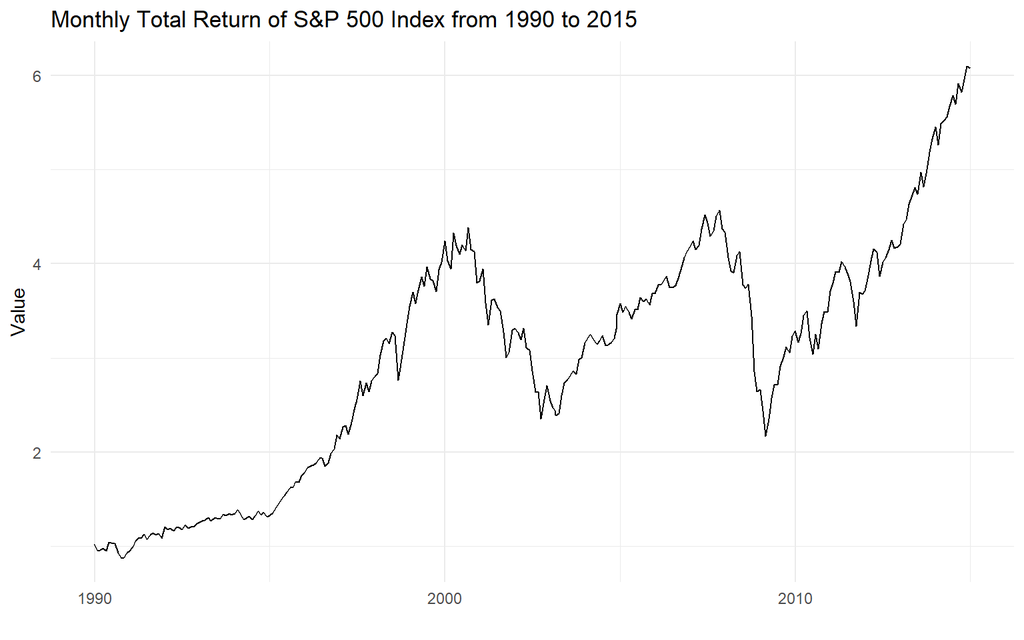

```r
# Plotting the returns of S&P 500
ggplot(data = SP500, aes(x = date)) +
  geom_line(aes(y = SP500_VALUE)) +
  theme_minimal() +
  theme(legend.position = "bottom") +
  labs(title = "Monthly Total Return of S&P 500 Index from 1990 to 2015",
       x = "",
       y = "Value")
```

> Similarly, looking at the S&P 500 index in the above figure, it is a good reflection of current events, with dips around political and financial crisis (2001, 2008). However, it exhibits a steady growth after recovering from 2008, with a slight dip around presidential elections (for instance 2012) which could reflect uncertainty and caution at the time.

## Q3

```r
# Log returns for Microsoft
MSFT$MSFT_LRET <- log(1 + MSFT$MSFT_RET)

# Log returns for GE
GE$GE_LRET <- log(1 + GE$GE_RET)

# Log returns for S&P 500
SP500$SP500_LRET <- log(1 + SP500$SP500_RET)
```

```r
# Statistics
data.frame(`MSFT Normal` = c(mean(MSFT$MSFT_RET), var(MSFT$MSFT_RET), skewness(MSFT$MSFT_RET), kurtosis(MSFT$MSFT_RET)),
           `GE Normal` = c(mean(GE$GE_RET), var(GE$GE_RET), skewness(GE$GE_RET), kurtosis(GE$GE_RET)),
           `SP500 Normal` = c(mean(SP500$SP500_RET), var(SP500$SP500_RET), skewness(SP500$SP500_RET), kurtosis(SP500$SP500_RET)),
           `MSFT Log` = c(mean(MSFT$MSFT_LRET), var(MSFT$MSFT_LRET), skewness(MSFT$MSFT_LRET), kurtosis(MSFT$MSFT_LRET)),
           `GE Log` = c(mean(GE$GE_LRET), var(GE$GE_LRET), skewness(GE$GE_LRET), kurtosis(GE$GE_LRET)),
           `SP500 Log` = c(mean(SP500$SP500_LRET), var(SP500$SP500_LRET), skewness(SP500$SP500_LRET), kurtosis(SP500$SP500_LRET)),
row.names = c("Mean", "Variance", "Skewness", "Kurtosis")) %>%
  mutate_if(is.numeric, round, digits = 4) %>%
  kbl() %>%
  kable_classic_2(font_size = 20) %>%
  add_header_above(c(" " = 1, "Normal Return" = 3, "Log Return" = 3))
```

|  | Normal Return MSFT.Normal | Normal Return GE.Normal | Normal Return SP500.Normal | Log Return MSFT.Log | Log Return GE.Log | Log Return SP500.Log |
| --- | --- | --- | --- | --- | --- | --- |
| Mean | 0.0200 | 0.0103 | 0.0069 | 0.0157 | 0.0076 | 0.0060 |
| Variance | 0.0087 | 0.0052 | 0.0018 | 0.0083 | 0.0053 | 0.0018 |
| Skewness | 0.4442 | -0.1845 | -0.6288 | -0.1019 | -0.5941 | -0.8170 |
| Kurtosis | 5.0407 | 4.5178 | 4.2318 | 5.2605 | 5.3712 | 4.7326 |

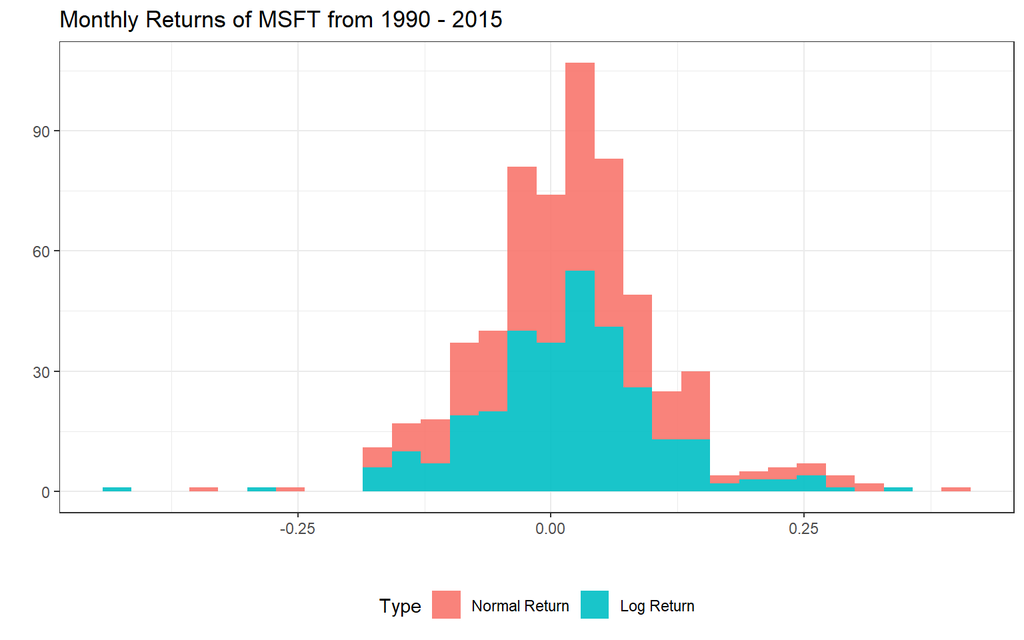

```r
MSFT %>%
  select(`Normal Return` = MSFT_RET, `Log Return` = MSFT_LRET) %>%
  pivot_longer(everything(), names_to = "Type", values_to = "Return") %>%
  mutate(Type = factor(Type, levels = c("Normal Return", "Log Return"))) %>%
  ggplot(aes(x = Return, fill = Type)) +
    geom_histogram(bins = 30, alpha = 0.9) +
    theme_bw() +
    theme(legend.position = "bottom") +
    labs(title = "Monthly Returns of MSFT from 1990 - 2015",
         x = "",
         y = "")
```

## Q4

> Two additional data sheets are downloaded, HPR Daily and Prices Daily. HPR Daily contains the daily holding period returns for the six stocks, the S&P 500 Composite Index and the value-weighted market portfolio (including dividends) from CRSP. Prices Daily contains the prices for the six stocks and the S&P 500 Composite Index.

```r
# loading HPR Daily Sheet
daily_ret_data <- read_excel(here("Data", "PS1_Daily.xlsx"), sheet = "HPR_daily")
colnames(daily_ret_data) <- paste0(daily_ret_data[1,], "_RET")
daily_ret_data <- daily_ret_data[-1,]

# loading Prices Daily Sheet
daily_price_data <- read_excel(here("Data", "PS1_Daily.xlsx"), sheet = "Prices_daily")
colnames(daily_price_data) <- paste0(daily_price_data[1,], "_PRICE")
daily_price_data <- daily_price_data[-1,]

# Joining the HPR and Prices data
daily_data <- daily_ret_data %>%
  rename(date = DATE_RET) %>%
  left_join(daily_price_data %>% rename(date = DATE_PRICE), by = "date")

# removing the datasets
rm(daily_ret_data, daily_price_data)

# Looking at the final data
glimpse(daily_data)
```

```
## Rows: 6,301
## Columns: 16
## $ date         <chr> "1990-01-02", "1990-01-03", "1990-01-04", "1990-01-05", "~
## $ MSFT_RET     <chr> "2.0115000000000001E-2", "5.6340000000000001E-3", "2.9412~
## $ XOM_RET      <chr> "0", "-0.01", "-1.0101000000000001E-2", "-5.1019999999999~
## $ GE_RET       <chr> "3.4883999999999998E-2", "-1.8730000000000001E-3", "-5.62~
## $ JPM_RET      <chr> "4.1840000000000002E-3", "3.3333000000000002E-2", "4.032E~
## $ INTC_RET     <chr> "4.3478000000000003E-2", "-2.7778000000000001E-2", "2.142~
## $ C_RET        <chr> "3.0702E-2", "1.2766E-2", "-1.2605E-2", "8.51099999999999~
## $ VWRETD_RET   <chr> "1.4433E-2", "2.1999999999999999E-5", "-6.486999999999999~
## $ SPRTRN_RET   <chr> "1.7798999999999999E-2", "-2.5860000000000002E-3", "-8.61~
## $ MSFT_PRICE   <chr> "88.75", "89.25", "91.875", "89.625", "91", "90.75", "88.~
## $ XOM_PRICE    <chr> "50", "49.5", "49", "48.75", "49.5", "48.5", "48.75", "49~
## $ GE_PRICE     <chr> "66.75", "66.625", "66.25", "65.625", "66", "64.625", "64~
## $ JPM_PRICE    <chr> "30", "31", "31.125", "31.25", "31.25", "30.25", "30.125"~
## $ INTC_PRICE   <chr> "36", "35", "35.75", "35.5", "36", "37", "36", "36", "35.~
## $ C_PRICE      <chr> "29.375", "29.75", "29.375", "29.625", "29.875", "29.5", ~
## $ SPINDX_PRICE <chr> "359.69000199999999", "358.76001000000002", "355.67001299~
```

```r
# Convert date column to date variable
daily_data$date <- ymd(daily_data$date)

# Convert all other columns to numeric
daily_data <- daily_data %>% mutate_if(is.character, as.numeric)
```

## Q5

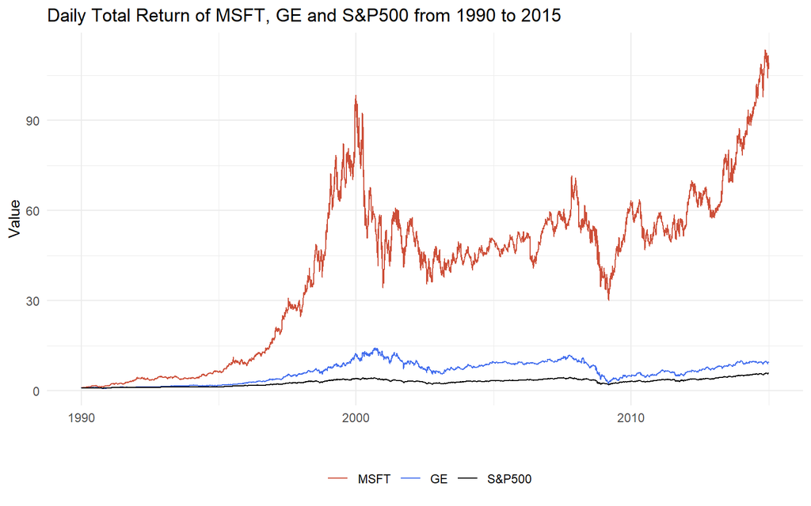

```r
MSFT_GE_SP500 <- daily_data %>%
  select(date, MSFT_RET, GE_RET, SPRTRN_RET) %>%
  mutate(MSFT_VALUE = cumprod(1 + MSFT_RET),
         GE_VALUE = cumprod(1 + GE_RET),
         SPRTRN_VALUE = cumprod(1 + SPRTRN_RET))

# Plotting the daily total return of Microsoft, GE and S&P500
ggplot(data = MSFT_GE_SP500, aes(x = date)) +
  geom_line(aes(y = MSFT_VALUE, color = "MSFT")) +
  geom_line(aes(y = GE_VALUE, color = "GE")) +
  geom_line(aes(y = SPRTRN_VALUE, color = "S&P500")) +
  scale_colour_manual("",
                      breaks = c("MSFT", "GE", "S&P500"),
                      values = c("tomato3", "royalblue2", "black")) +
  theme_minimal() +
  theme(legend.position = "bottom") +
  labs(title = "Daily Total Return of MSFT, GE and S&P500 from 1990 to 2015",
      x = "",
      y = "Value")
```

> As established in the above comments, the daily total returns exhibit a similar pattern to the monthly ones with dividends reinvested. Microsoft’s high risk and potential returns is quite clear in this figure. Both Microsoft and GE’s have exhibited higher return than the S&P500 index.

## Q6

```r
# Log return of Microsoft
MSFT_GE_SP500$MSFT_LRET <- log(1 + MSFT_GE_SP500$MSFT_RET)
# Log return of GE
MSFT_GE_SP500$GE_LRET <- log(1 + MSFT_GE_SP500$GE_RET)
# Log return of S&P500
MSFT_GE_SP500$SPRTRN_LRET <- log(1 + MSFT_GE_SP500$SPRTRN_RET)
```

```r
# Statistics
data.frame(`MSFT Normal` = c(mean(MSFT_GE_SP500$MSFT_RET), var(MSFT_GE_SP500$MSFT_RET), skewness(MSFT_GE_SP500$MSFT_RET), kurtosis(MSFT_GE_SP500$MSFT_RET)),
           `GE Normal` = c(mean(MSFT_GE_SP500$GE_RET), var(MSFT_GE_SP500$GE_RET), skewness(MSFT_GE_SP500$GE_RET), kurtosis(MSFT_GE_SP500$GE_RET)),
           `SP500 Normal` = c(mean(MSFT_GE_SP500$SPRTRN_RET), var(MSFT_GE_SP500$SPRTRN_RET), skewness(MSFT_GE_SP500$SPRTRN_RET),
                              kurtosis(MSFT_GE_SP500$SPRTRN_RET)),
           `MSFT Log` = c(mean(MSFT_GE_SP500$MSFT_LRET), var(MSFT_GE_SP500$MSFT_LRET), skewness(MSFT_GE_SP500$MSFT_LRET), kurtosis(MSFT_GE_SP500$MSFT_LRET)),
           `GE Log` = c(mean(MSFT_GE_SP500$GE_LRET), var(MSFT_GE_SP500$GE_LRET), skewness(MSFT_GE_SP500$GE_LRET), kurtosis(MSFT_GE_SP500$GE_LRET)),
           `SP500 Log` = c(mean(MSFT_GE_SP500$SPRTRN_LRET), var(MSFT_GE_SP500$SPRTRN_LRET), skewness(MSFT_GE_SP500$SPRTRN_LRET),
                           kurtosis(MSFT_GE_SP500$SPRTRN_LRET)),
row.names = c("Mean", "Variance", "Skewness", "Kurtosis")) %>%
  mutate_if(is.numeric, round, digits = 5) %>%
  kbl() %>%
  kable_classic_2(font_size = 20) %>%
  add_header_above(c(" " = 1, "Normal Return" = 3, "Log Return" = 3))
```

|  | Normal Return MSFT.Normal | Normal Return GE.Normal | Normal Return SP500.Normal | Log Return MSFT.Log | Log Return GE.Log | Log Return SP500.Log |
| --- | --- | --- | --- | --- | --- | --- |
| Mean | 0.00096 | 0.00052 | 0.00034 | 0.00074 | 0.00036 | 0.00028 |
| Variance | 0.00043 | 0.00032 | 0.00013 | 0.00043 | 0.00032 | 0.00013 |
| Skewness | 0.25041 | 0.28578 | -0.05633 | 0.01352 | 0.00496 | -0.24041 |
| Kurtosis | 8.79744 | 11.89206 | 11.86602 | 8.57172 | 11.21171 | 11.75141 |

> Looking at the statistics for daily returns, we find that Microsoft still exhibited the highest risk and highest return, with the largest variance and highest mean return (both log and simple). However, the scale of both mean and variance is significantly smaller than the monthly return situation, which is expected since day-to-day changes in returns would be generally less volatile and prices may revert often. Similarly to monthly situation, SP500 exhibits low variance as a benchmark. Additionally, Microsoft has the least outliers, with the lowest kurtosis.

> Simple daily return rates can be compounded to get the monthly returns, which is given by the following equation (assuming 20-day trading period per month).

> $\text { Monthly return }=\left[(\text { Daily return }+1)^{20}-1\right] * 100$

> On the other hand, log daily returns are additive and can be directly added up to get the monthly returns, which is more straightforward.

## Q7

Statistical Properties

```r
data.frame(`MSFT Normal` = c(mean(MSFT_GE_SP500$MSFT_RET), var(MSFT_GE_SP500$MSFT_RET), skewness(MSFT_GE_SP500$MSFT_RET), kurtosis(MSFT_GE_SP500$MSFT_RET)),
           `MSFT Log` = c(mean(MSFT_GE_SP500$MSFT_LRET), var(MSFT_GE_SP500$MSFT_LRET), skewness(MSFT_GE_SP500$MSFT_LRET), kurtosis(MSFT_GE_SP500$MSFT_LRET)),
           `GE Normal` = c(mean(MSFT_GE_SP500$GE_RET), var(MSFT_GE_SP500$GE_RET), skewness(MSFT_GE_SP500$GE_RET), kurtosis(MSFT_GE_SP500$GE_RET)),
           `GE Log` = c(mean(MSFT_GE_SP500$GE_LRET), var(MSFT_GE_SP500$GE_LRET), skewness(MSFT_GE_SP500$GE_LRET), kurtosis(MSFT_GE_SP500$GE_LRET)),
           `SP500 Normal` = c(mean(MSFT_GE_SP500$SPRTRN_RET), var(MSFT_GE_SP500$SPRTRN_RET), skewness(MSFT_GE_SP500$SPRTRN_RET),
                              kurtosis(MSFT_GE_SP500$SPRTRN_RET)),
           `SP500 Log` = c(mean(MSFT_GE_SP500$SPRTRN_LRET), var(MSFT_GE_SP500$SPRTRN_LRET), skewness(MSFT_GE_SP500$SPRTRN_LRET),
                           kurtosis(MSFT_GE_SP500$SPRTRN_LRET)),
row.names = c("Mean", "Variance", "Skewness", "Kurtosis")) %>%
  mutate_if(is.numeric, round, digits = 5) %>%
  kbl() %>%
  kable_classic_2(font_size = 20) %>%
  add_header_above(c(" " = 1, "MSFT" = 2, "GE" = 2, "SP500" = 2))
```

|  | MSFT MSFT.Normal | MSFT MSFT.Log | GE GE.Normal | GE GE.Log | SP500 SP500.Normal | SP500 SP500.Log |
| --- | --- | --- | --- | --- | --- | --- |
| Mean | 0.00096 | 0.00074 | 0.00052 | 0.00036 | 0.00034 | 0.00028 |
| Variance | 0.00043 | 0.00043 | 0.00032 | 0.00032 | 0.00013 | 0.00013 |
| Skewness | 0.25041 | 0.01352 | 0.28578 | 0.00496 | -0.05633 | -0.24041 |
| Kurtosis | 8.79744 | 8.57172 | 11.89206 | 11.21171 | 11.86602 | 11.75141 |

Histogram

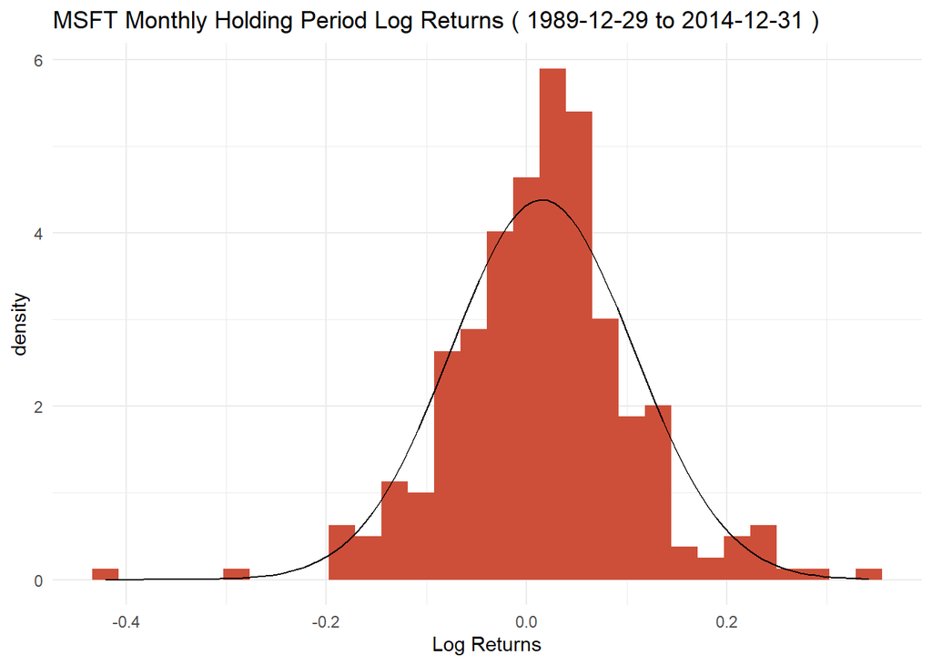

```r
# MSFT
MSFT %>%
  ggplot()+
  geom_histogram(aes(x = MSFT_LRET, y = ..density..), fill = "tomato3")+
  stat_function(fun = dnorm, args = list(mean = mean(MSFT$MSFT_LRET),
                                           sd = sd(MSFT$MSFT_LRET)))+
  labs(x = "Log Returns", title = paste("MSFT Monthly Holding Period Log Returns", "(", min(MSFT$date), "to", max(MSFT$date), ")"))+
  theme_minimal()
```

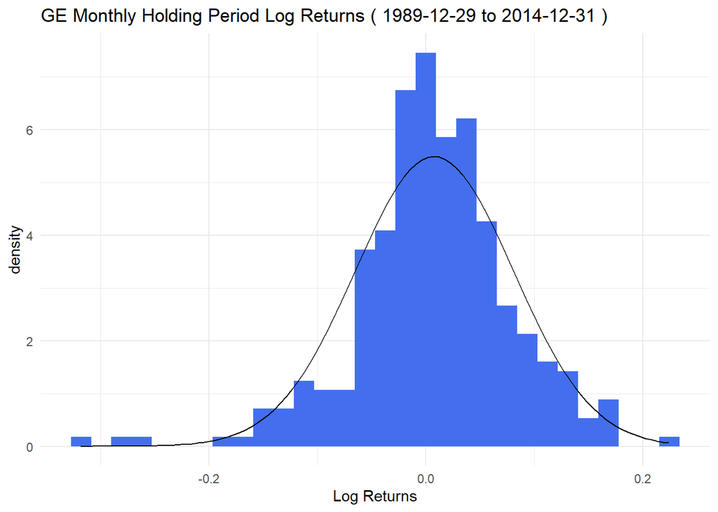

```r
# GE
GE %>%
  ggplot()+
  geom_histogram(aes(x = GE_LRET, y = ..density..), fill = "royalblue2")+
  stat_function(fun = dnorm, args = list(mean = mean(GE$GE_LRET),
                                           sd = sd(GE$GE_LRET)))+
  labs(x = "Log Returns", title = paste("GE Monthly Holding Period Log Returns", "(", min(GE$date), "to", max(GE$date), ")"))+
  theme_minimal()
```

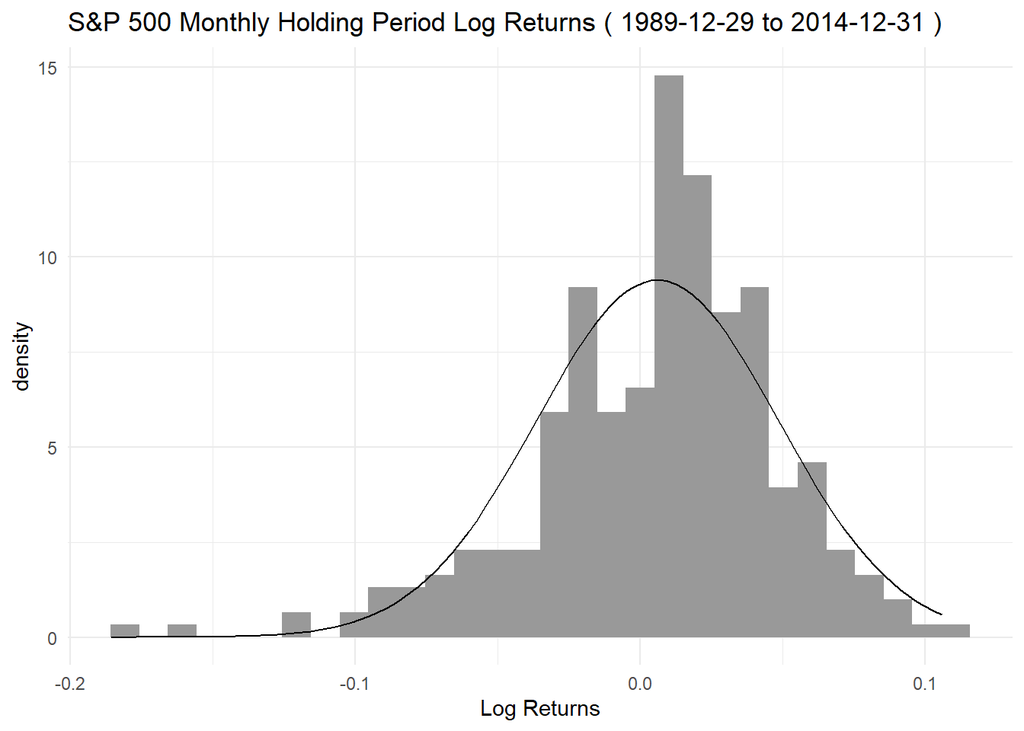

```r
# S&P500
SP500 %>%
  ggplot()+
  geom_histogram(aes(x = SP500_LRET, y = ..density..), fill = "grey60")+
  stat_function(fun = dnorm, args = list(mean = mean(SP500$SP500_LRET),
                                           sd = sd(SP500$SP500_LRET)))+
  labs(x = "Log Returns", title = paste("S&P 500 Monthly Holding Period Log Returns", "(", min(SP500$date), "to", max(SP500$date), ")"))+
  theme_minimal()
```

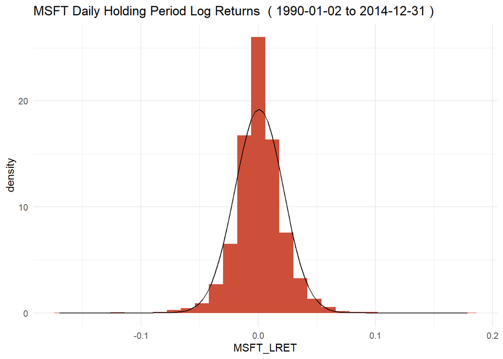

```r
# MSFT
MSFT_GE_SP500 %>%
  ggplot()+
    geom_histogram(aes(x = MSFT_LRET, y = ..density..), fill = "tomato3")+
    stat_function(fun = dnorm, args = list(mean = mean(MSFT_GE_SP500$MSFT_LRET), sd = sd(MSFT_GE_SP500$MSFT_LRET)))+
    labs(title = paste("MSFT Daily Holding Period Log Returns ", "(", min(MSFT_GE_SP500$date), "to", max(MSFT_GE_SP500$date), ")"))+
    theme_minimal()
```

[figure not shown]

```r
# GE
MSFT_GE_SP500 %>%
  ggplot()+
    geom_histogram(aes(x = GE_LRET, y = ..density..), fill = "royalblue2")+
    stat_function(fun = dnorm, args = list(mean = mean(MSFT_GE_SP500$GE_LRET), sd = sd(MSFT_GE_SP500$GE_LRET)))+
    labs(title = paste("MSFT Daily Holding Period Log Returns ", "(", min(MSFT_GE_SP500$date), "to", max(MSFT_GE_SP500$date), ")"))+
    theme_minimal()
```

[figure not shown]

```r
# S&P500
MSFT_GE_SP500 %>%
  ggplot()+
    geom_histogram(aes(x = SPRTRN_LRET, y = ..density..), fill = "grey60")+
    stat_function(fun = dnorm, args = list(mean = mean(MSFT_GE_SP500$SPRTRN_LRET), sd = sd(MSFT_GE_SP500$SPRTRN_LRET)))+
    labs(title = paste("MSFT Daily Holding Period Log Returns ", "(", min(MSFT_GE_SP500$date), "to", max(MSFT_GE_SP500$date), ")"))+
    theme_minimal()
```

> The empirical distributions of the monthly and daily log returns for the three chosen stocks are all normal looking in that they are roughly symmetrical without very obvious skewness, probably due to Central Limit Therom given the large data set we use. However, the monthly distributions exhibit a bit of left skew, especially for GE and S&P 500, probably due to some negative market shocks.

## Q8

```r
tickers <- c("MSFT", "XOM", "GE", "JPM", "INTC", "C")
set.seed(1234)
sample_tickers = sample(tickers, 3)

# Holding period returns
selection <- daily_data %>%
  select(date, starts_with(sample_tickers) & ends_with("RET"), SPRTRN_RET)

# Log return
selection_LRET <- as.data.frame(apply(selection %>%
                                        select(ends_with("RET")) + 1, MARGIN = 2, FUN = log))
colnames(selection_LRET) <- c(paste0(sample_tickers, "_LRET"), "SPRTRN_LRET")

# Total return indexes
selection_VALUE <- as.data.frame(apply(selection %>%
                                      select(ends_with("RET")) + 1, MARGIN = 2, FUN = cumprod))
colnames(selection_VALUE) <- c(paste0(sample_tickers, "_VALUE"), "SPRTRN_VALUE")

# Combining HPR, Log and Total returns
selection <- selection %>%
  cbind(selection_LRET) %>%
  cbind(selection_VALUE)

# removing data frames
rm(selection_LRET, tickers)
```

> In this section, three random stocks are selected, in this case JP Morgan, Exxon Mobile and Intel, and a data frame is created with the normal and log returns of the holding period and the total return indices for these three stocks and the S&P500. This allows us to compare stock returns directly and calculate the covariance between them in the following question.

## Q9

```r
# Covariance matrix for Log returns
cor(selection %>%
      select(ends_with("LRET")))
```

```
##              JPM_LRET  XOM_LRET INTC_LRET SPRTRN_LRET
## JPM_LRET    1.0000000 0.3350649 0.3833730   0.6956786
## XOM_LRET    0.3350649 1.0000000 0.2753722   0.6104161
## INTC_LRET   0.3833730 0.2753722 1.0000000   0.6053025
## SPRTRN_LRET 0.6956786 0.6104161 0.6053025   1.0000000
```

```r
# Covariance matrix Log returns squared
cor((selection %>% select(ends_with("LRET")))^2)
```

```
##              JPM_LRET  XOM_LRET INTC_LRET SPRTRN_LRET
## JPM_LRET    1.0000000 0.2381203 0.1659690   0.5374612
## XOM_LRET    0.2381203 1.0000000 0.1689921   0.7178163
## INTC_LRET   0.1659690 0.1689921 1.0000000   0.3014405
## SPRTRN_LRET 0.5374612 0.7178163 0.3014405   1.0000000
```

> The covariance allows us to measure the directional measure between two stock returns, meaning how stocks may perform relative to each other. More specifically, covariance is calculated using the formula:

> $$\sigma_i,_j = \frac{1}{N-1}\sum_{i = 1}^{N}{(r_i - \bar{r_i})(r_j - \bar{r_j})}$$

> Where $\sigma$ is the covariance, $N$ the sample size, $r$ the return and $\bar{r}$ the average return for stocks $i$ and $j$. In this case, we evaluate and compare logarithmic returns of JPM, XOM, INTC and the S&P500.

> Looking at the 1st covariance table (using normal log returns), we immediately observe that all covariance values are positive, meaning that all stocks tend to move together; ie. if XOM has a positive return, JPM will tend to have a positive return as well and viceversa. We can also see that highest covariance (>0.6) comes when including the S&P in the comparison. This is logical as the S&P provides a broad indication of the market performance each day, and the stocks being analysed contribute to the S&P500 performance as they are part of the index. Lastly, covariance between JPM, XOM and INTC is in all cases around 0.3, with the lowest covariance being between XOM and INTC (~0.275) and the highest between JPM and INTC (~0.383).

> Using squared log returns, we can obtain a proxy of daily volatility, allowing us to understand the risk of each stock. Using these and calculating the covariance matrix for all our stocks, we observe whether high daily volatility of one stock can indicate high daily volatility for another. From the matrix obtained, we once again observe highest covariance when stocks are compared to the S&P (0.71 for XOM, 0.54 for JPM and 0.30 for INTC) and a covariance of around ~0.18 when comparing XOM, JPM and INTC between one another. Overall, covariance values are lower than the ones using normal returns, meaning that daily volatility for one stock is less of a valuable indicator of the volatility of another stock.

> Using this information, when building a portfolio, we may want to select stocks with low covariance between each other, obtaining stocks that move opposite to each other and hence diversifying and reducing risk while obtaining the same expected return.

## Q10

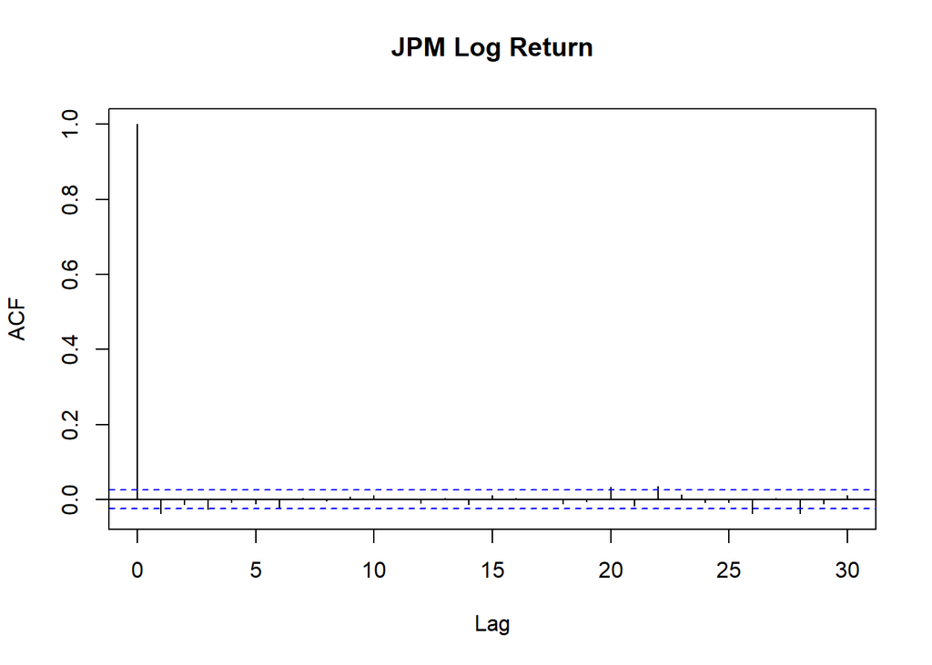

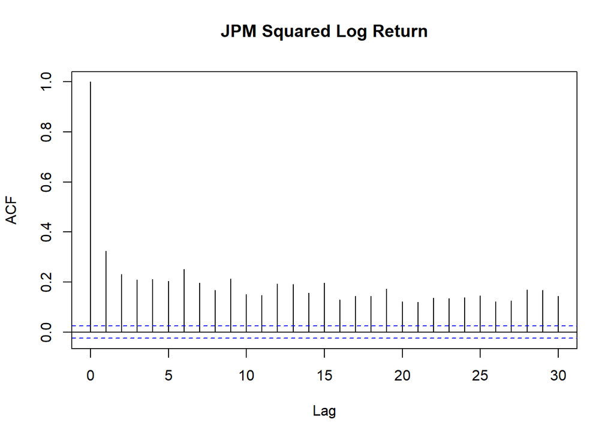

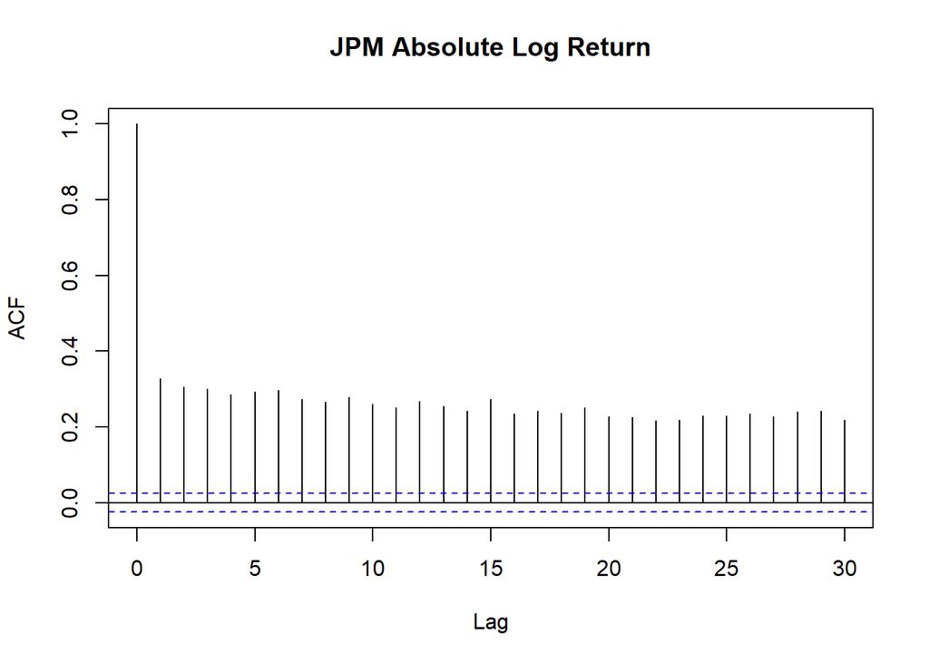

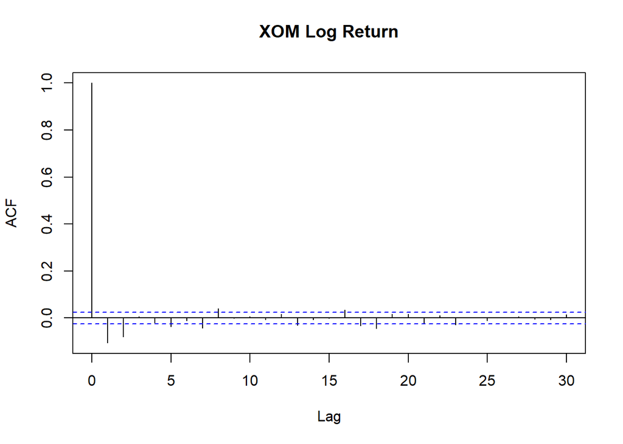

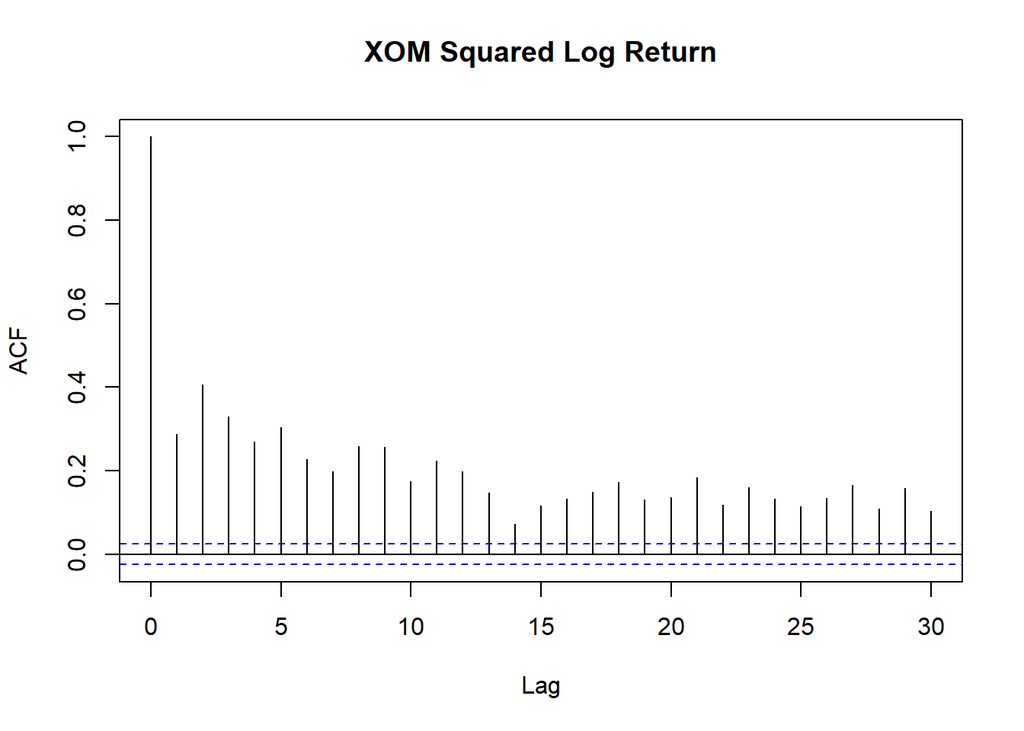

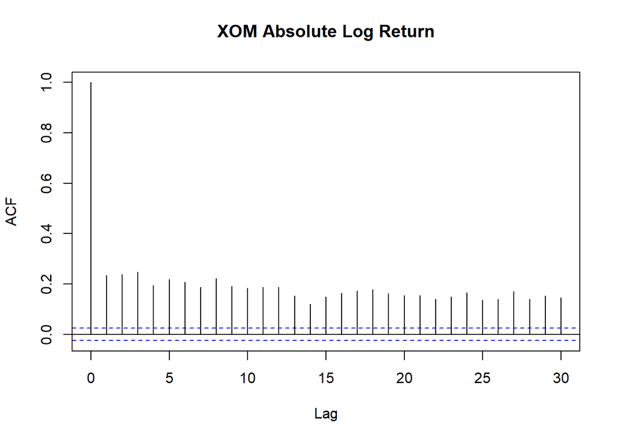

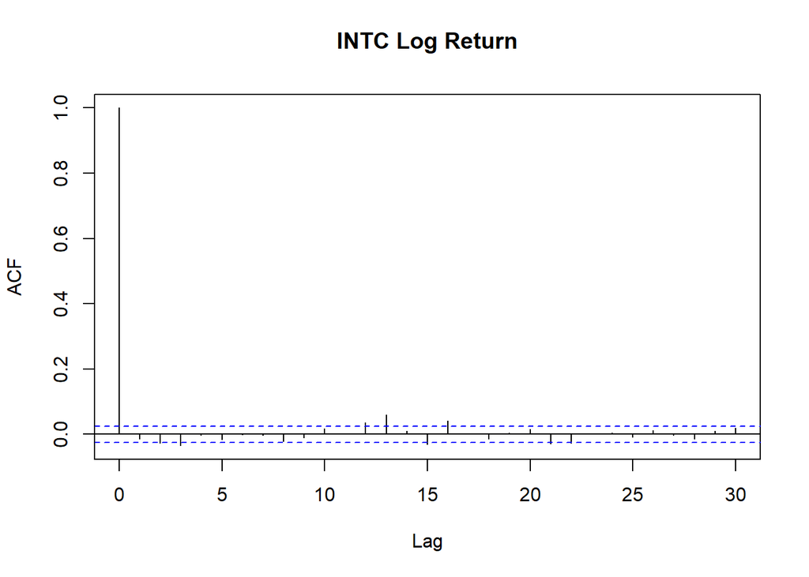

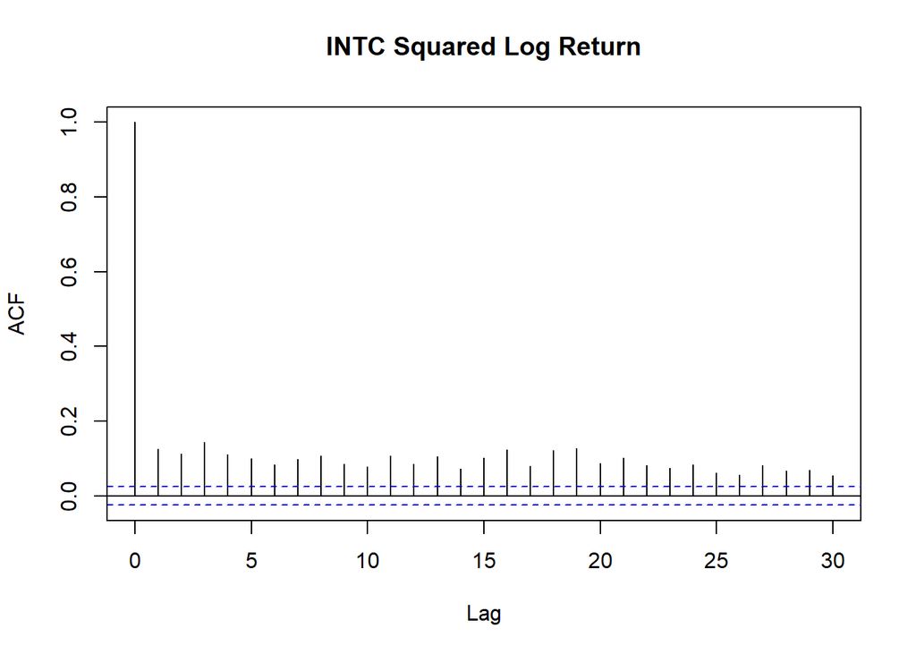

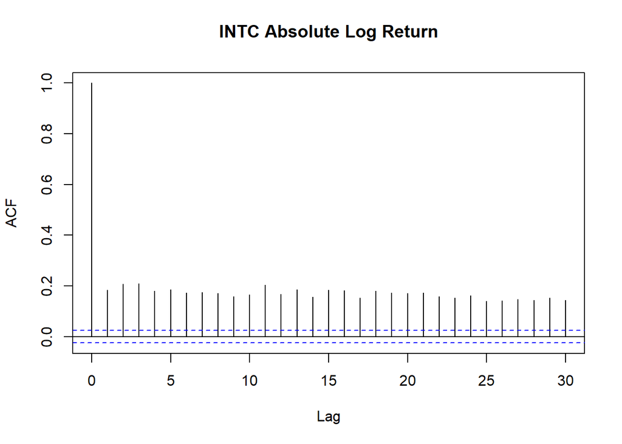

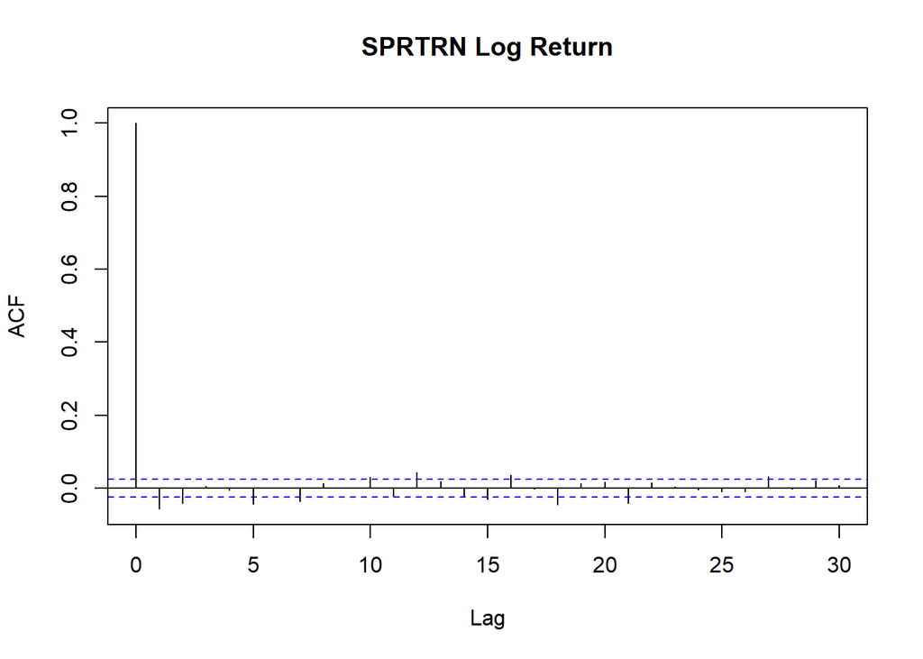

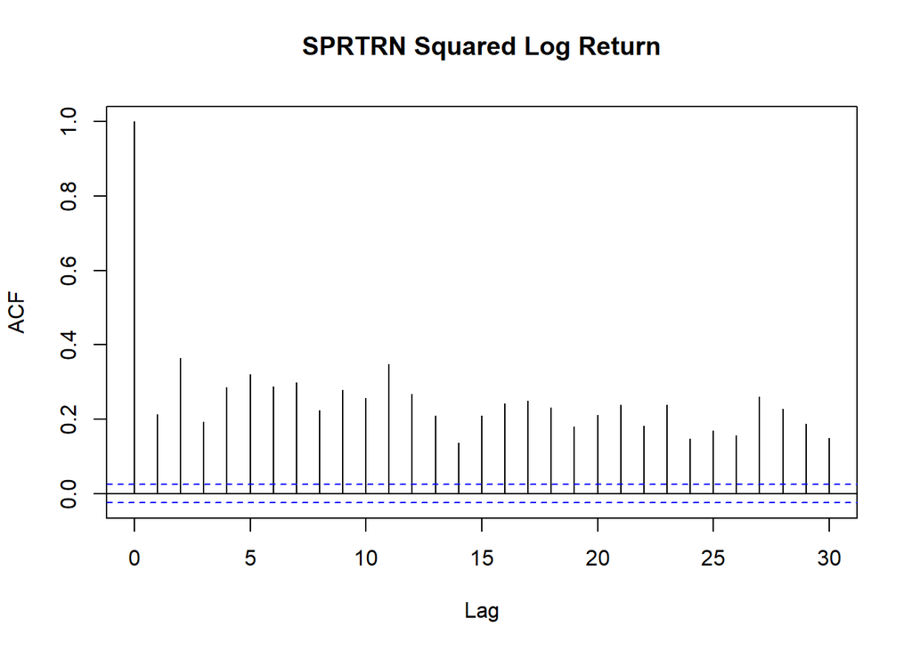

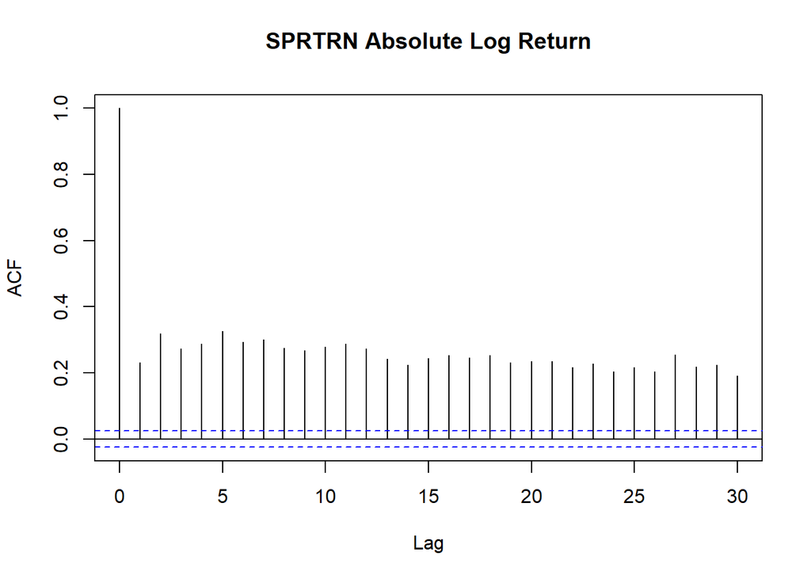

```r
for (ticker in c(sample_tickers, "SPRTRN")) {
  acf(selection %>% select(starts_with(ticker) & ends_with("LRET")), lag.max = 30, main = paste0(ticker, " Log Return"))
  acf((selection %>% select(starts_with(ticker) & ends_with("LRET")))^2, lag.max = 30, main = paste0(ticker, " Squared Log Return"))
  acf(abs(selection %>% select(starts_with(ticker) & ends_with("LRET"))), lag.max = 30, main = paste0(ticker, " Absolute Log Return"))
}
```

> From the ACF plots of log return for all three stocks and S&P 500 index, we observe that the correlation coefficient between the return of a stock on a particular day is negative correlated to the return of the same stock on previous days. This suggest the phenomenon of correction in stock prices.

> From the ACF plots of absolute log return, we can see that correlation coefficients drops when lag increase. This means that the return of a stock on a particular day is influenced more by returns of recent days than returns of days long past. We are able to see similar patterns from the ACF plots of squared log return.

## Q11

```r
# assigning portfolio weights
arbitrary_weights <- c(1/3, 1/3, 1/3)

#portfolio
portfolio <- selection %>%
  select(date, starts_with(sample_tickers) & ends_with("RET") & !ends_with("LRET"))
```

> We have arbitrarily assigned the equal weights to the chosen three stocks. However, if we keep the weights fixed over time then we will be unable to benefit that much from the diversification of the assets in the portfolio. The purpose of the assigning weights is to safeguards the investors from undesirable risks. A stock’s performance can vary over time, thus the percentage of the funds associated with the stocks will require a change with a change in the market conditions. Changing weights of the assets in the portfolio gives investors the opportunity to sell high and buy low, taking the gains from high-performing investments.

## Q12

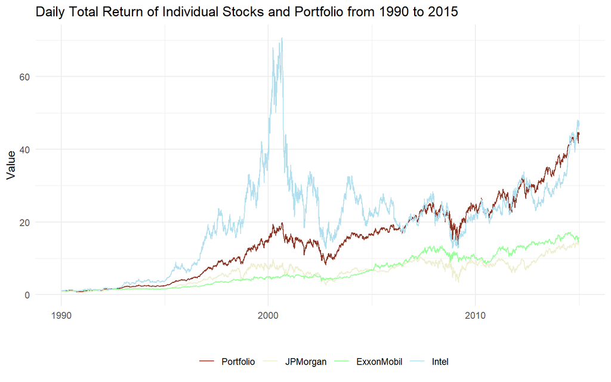

```r
# Portfolio return
portfolio$Portfolio_RET <- as(portfolio %>%
                                select(starts_with(sample_tickers)), "matrix") %*% arbitrary_weights

# Portfolio total return index
portfolio$Portfolio_VALUE <- cumprod(1 + portfolio$Portfolio_RET)

# Single stock total return index
portfolio <- cbind(portfolio, selection_VALUE %>% select(starts_with(sample_tickers)))

# Plotting
ggplot(portfolio, aes(x = date)) +
  geom_line(aes(y = Portfolio_VALUE, color = "Portfolio")) +
  geom_line(aes(y = JPM_VALUE, color = "JPMorgan")) +
  geom_line(aes(y = XOM_VALUE, color = "ExxonMobil")) +
  geom_line(aes(y = INTC_VALUE, color = "Intel")) +
  scale_colour_manual("",
                      breaks = c("Portfolio", "JPMorgan", "ExxonMobil", "Intel"),
                      values = c("tomato4", "lightyellow2", "palegreen1", "lightblue2")) +
  theme_minimal() +
  theme(legend.position = "bottom") +
  labs(title = "Daily Total Return of Individual Stocks and Portfolio from 1990 to 2015",
       x = "",
       y = "Value")
```

> By spreading the capital across multiple assets in a portfolio instead of investing in individual stocks, investors can reap benefits. Diversification into multiple stocks will help to protect an investor’s capital when one individual stock is not performing well. The graph above clearly shows that the portfolio’s value is much more stable compared to that of highly volatile Intel’s stock. Additionally, portfolio’s performance has improved against low performing JPMorgan and ExxonMobil individual stocks. Hence, we can conclude portfolio investment is able to deliver a balanced rate of return that is on average better than individual investment returns, because of the risk diversification among various investments inside a portfolio.

## Conclusion

From the analysis of historical data of six assets, we have been able to identify the differences between calculating logarithmic and normal returns and between daily and monthly returns, as well as how returns and risk of different assets may be correlated to each other and how their current value is related to their past value. Most notably, we identified that log returns are preferred when having a look at time series data, as the compounding effect is captured more effectively and can be understood more intuitively. Having done that, a portfolio of three different assets was created and returns obtained from the portfolio were compared to investing in each asset individually, identifying that diversification and portfolio creation can lead to a more balanced rate of return and risk reduction.